# Park_Lab2

Patty Park

1/24/2024

Today we will be continuing the pumpkin case study from last week. We will be using the data that you cleaned and split last time (pumpkins_train) and will be comparing our results today to those you have already obtained. Open and run your Lab 1.Rmd as a first step so those objects are available in your Environment.

Once you have done that, we’ll start today’s lab by specifying a recipe for a polynomial model. First we specify a recipe that identifies our variables and data, converts the package variable to a numerical form, and then adds a polynomial effect with step_poly()

```r
# Specify a recipe
poly_pumpkins_recipe <-
  recipe(price ~ package, data = pumpkins_train) %>%
  step_integer(all_predictors(), zero_based = TRUE) %>%
  step_poly(all_predictors(), degree = 4)
```

How did that work? Later we will learn about model tuning that will let us do things like find the optimal value for degree. For now, we’d like to have a flexible model, so we’ll use a relatively large value.

Polynomial regression is still linear regression, so our model specification looks similar to before.

```r
# Create a model specification called poly_spec
poly_spec <- linear_reg() %>%
  set_engine("lm") %>%
  set_mode("regression")
```

```r
# Bundle recipe and model spec into a workflow
poly_wf <- workflow() %>%
  add_recipe(poly_pumpkins_recipe) %>%
  add_model(poly_spec)
```

Question 2: fit a model to the pumpkins_train data using your workflow and assign it to poly_wf_fit

```r
# Create a model
poly_wf_fit <- fit(poly_wf, pumpkins_train)
```

```r
# Print learned model coefficients
poly_wf_fit
```

```
## ══ Workflow [trained] ══════════════════════════════════════════════════════════
## Preprocessor: Recipe
## Model: linear_reg()
##
## ── Preprocessor ────────────────────────────────────────────────────────────────
## 2 Recipe Steps
##
## • step_integer()
## • step_poly()
##
## ── Model ───────────────────────────────────────────────────────────────────────
##
## Call:
## stats::lm(formula = ..y ~ ., data = data)
##
## Coefficients:
##    (Intercept)  package_poly_1  package_poly_2  package_poly_3  package_poly_4
##        27.9706        103.8566       -110.9068        -62.6442          0.2677
```

```r
# Make price predictions on test data
poly_results <- poly_wf_fit %>% predict(new_data = pumpkins_test) %>%
  bind_cols(pumpkins_test %>% select(c(package, price))) %>%
  relocate(.pred, .after = last_col())

# Print the results
poly_results %>%
  slice_head(n = 10)
```

| package | price | .pred |
| --- | --- | --- |
| 1 1/9 bushel cartons | 13.63636 | 15.90410 |
| 1 1/9 bushel cartons | 16.36364 | 15.90410 |
| 1 1/9 bushel cartons | 16.36364 | 15.90410 |
| 1 1/9 bushel cartons | 13.63636 | 15.90410 |
| 1 1/9 bushel cartons | 15.45455 | 15.90410 |
| 1 1/9 bushel cartons | 16.36364 | 15.90410 |
| 1/2 bushel cartons | 34.00000 | 34.44086 |
| 1/2 bushel cartons | 30.00000 | 34.44086 |
| 1/2 bushel cartons | 30.00000 | 34.44086 |
| 1/2 bushel cartons | 34.00000 | 34.44086 |

Now let’s evaluate how the model performed on the test_set using yardstick::metrics().

```r
metrics(data = poly_results, truth = price, estimate = .pred)
```

| .metric | .estimator | .estimate |
| --- | --- | --- |
| rmse | standard | 3.2748876 |
| rsq | standard | 0.8916641 |
| mae | standard | 2.3485658 |

Question 3: How do the performance metrics differ between the linear model from last week and the polynomial model we fit today? Which model performs better on predicting the price of different packages of pumpkins?

- **Answer**: The performance metrics from last week has values that are farther away from zero than the performance metrics for this week. This week’s metrics are a much better fit for the model as the rmse and the rsq are at value to maximize the fit.

Let’s visualize our model results. First prep the results by binding the encoded package variable to them.

```r
# Bind encoded package column to the results
poly_results <- poly_results %>%
  bind_cols(package_encode %>%
              rename(package_integer = package)) %>%
  relocate(package_integer, .after = package)


# Print new results data frame
poly_results %>%
  slice_head(n = 5)
```

| package | package_integer | price | .pred |
| --- | --- | --- | --- |
| 1 1/9 bushel cartons | 0 | 13.63636 | 15.9041 |
| 1 1/9 bushel cartons | 0 | 16.36364 | 15.9041 |
| 1 1/9 bushel cartons | 0 | 16.36364 | 15.9041 |
| 1 1/9 bushel cartons | 0 | 13.63636 | 15.9041 |
| 1 1/9 bushel cartons | 0 | 15.45455 | 15.9041 |

OK, now let’s take a look!

Question 4: Create a scatter plot that takes the poly_results and plots package vs. price. Then draw a line showing our model’s predicted values (.pred). Hint: you’ll need separate geoms for the data points and the prediction line.

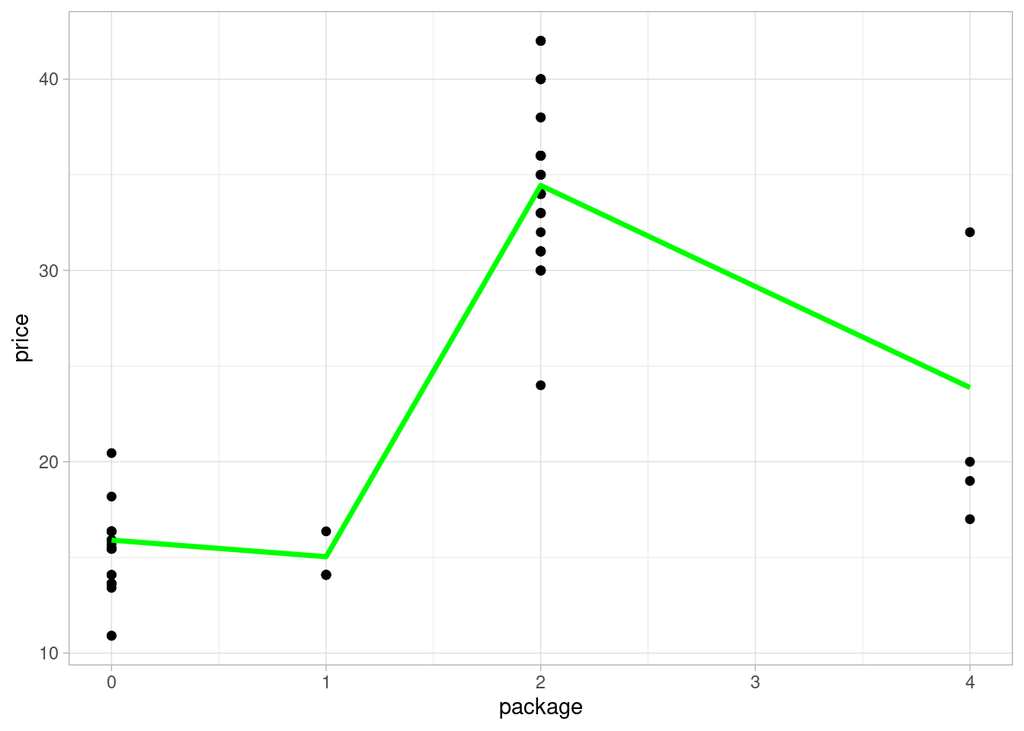

```r
# Make a scatter plot
poly_results %>% ggplot(mapping = aes(x = package_integer, y = price)) +
   geom_point(size = 1.6) +
   # Overlay a line of best fit
   geom_line(aes(y = .pred), color = "green", linewidth = 1.2) +
  xlab("package")
```

You can see that a curved line fits your data much better.

Question 5: Now make a smoother line by using geom_smooth instead of geom_line and passing it a polynomial formula like this: geom_smooth(method = lm, formula = y ~ poly(x, degree = 3), color = “midnightblue”, size = 1.2, se = FALSE)

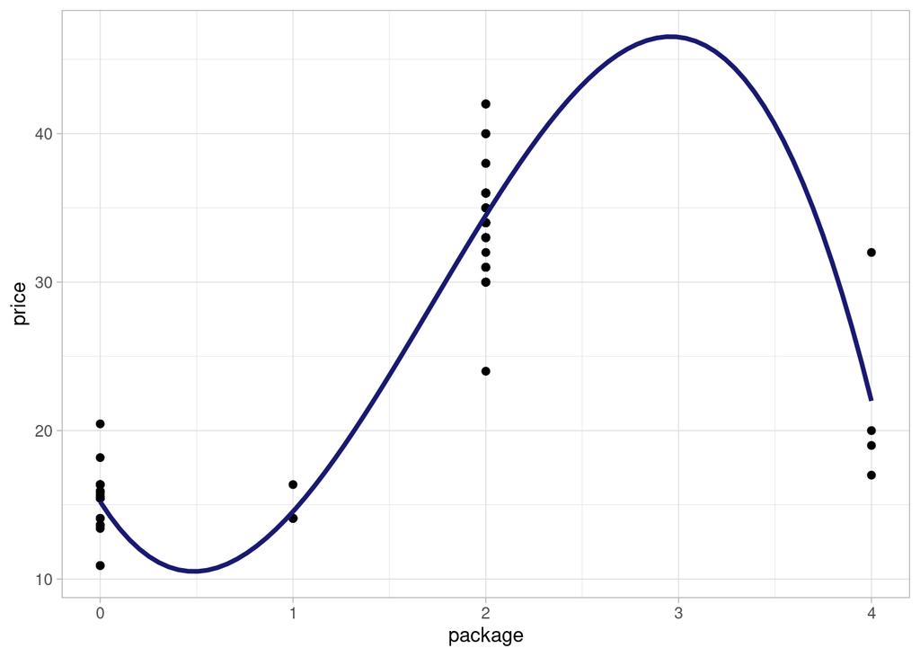

```r
# Make a smoother scatter plot
poly_results %>% ggplot(mapping = aes(x = package_integer, y = price)) +
   geom_point(size = 1.6) +
   # Overlay a line of best fit
   geom_smooth(method = lm, formula = y ~ poly(x, degree = 3), color = "midnightblue", size = 1.2, se = FALSE) +
  xlab("package")
```

OK, now it’s your turn to go through the process one more time.

Additional assignment components : 6. Choose a new predictor variable (anything not involving package type) in this dataset.

- **Answer**: I will go ahead and have my new predictor variable be city location. I am interested to see the prediction of what city will have the most pumpkins
7. Determine its correlation with the outcome variable (price). (Remember we calculated a correlation matrix last week)

```r
# Find the correlation between the city and the price
cor(baked_pumpkins$city_name, baked_pumpkins$price)
```

```
## [1] 0.3236397
```

8. Create and test a model for your new predictor:
- Create a recipe
- Build a model specification (linear or polynomial)
- Bundle the recipe and model specification into a workflow
- Create a model by fitting the workflow
- Evaluate model performance on the test data
- Create a visualization of model performance

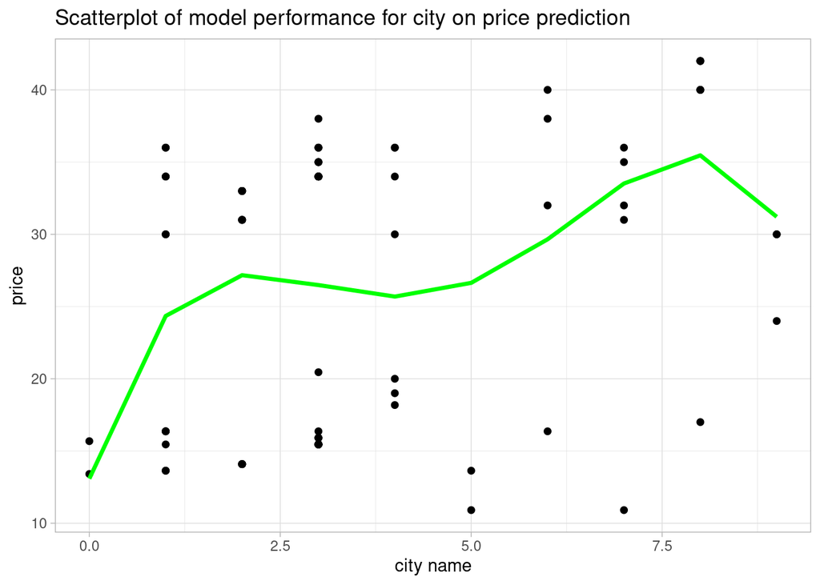

```r
# Create a recipe for preprocessing the data
lm_pumpkins_recipe_city <-
  recipe(price ~ city_name, data = pumpkins_train) %>% #using recipe function, will regress price on city_name, using data from pumpkins_train
  step_integer(all_predictors(), zero_based = TRUE) #add in integer step

# Create a recipe
poly_pumpkins_recipe_city <-
  recipe(price ~ city_name, data = pumpkins_train) %>% #using recipe function, will regress price on city_name, using data from pumpkins_train
  step_integer(all_predictors(), zero_based = TRUE) %>% #add in integer step
  step_poly(all_predictors(), degree = 4) #add in poly step

# Build a model specification (linear)
poly_spec_city <- linear_reg() %>%
  set_engine("lm") %>%
  set_mode("regression")

# Bundle the recipe and model specification into a workflow
poly_wf_city <- workflow() %>%
  add_recipe(poly_pumpkins_recipe_city) %>%
  add_model(poly_spec_city)

# Create a model by fitting the workflow
poly_wf_fit_city <- fit(poly_wf_city, pumpkins_train)

# Evaluate model performance on the test data
poly_results_city <- poly_wf_fit_city %>% predict(new_data = pumpkins_test) %>%
  bind_cols(pumpkins_test %>% select(c(city_name, price))) %>%
  relocate(.pred, .after = last_col())

# Encode package column
package_encode_city <- lm_pumpkins_recipe_city %>%
  prep() %>%
  bake(new_data = pumpkins_test) %>%
  select(city_name)

# Bind encoded package column to the results
poly_results_city <- poly_results_city %>%
  bind_cols(package_encode_city %>%
              rename(city_name_integer = city_name)) %>%
  relocate(city_name_integer, .after = city_name)

# Create a visualization of model performance:
# Make a scatter plot
poly_results_city %>% ggplot(mapping = aes(x = city_name_integer, y = price)) +
   geom_point(size = 1.6) +
   # Overlay a line of best fit
   geom_line(aes(y = .pred), color = "green", linewidth = 1.2) +
  xlab("city name") +
  labs(title = "Scatterplot of model performance for city on price prediction")
```

[figure not shown]

```r
# Make a smoother scatter plot
poly_results %>% ggplot(mapping = aes(x = package_integer, y = price)) +
   geom_point(size = 1.6) +
   # Overlay a line of best fit
   geom_smooth(method = lm, formula = y ~ poly(x, degree = 3), color = "midnightblue", size = 1.2, se = FALSE) +
  xlab("city name") +
  labs(title = "Scatterplot of smooth model performance for city on price prediction")
```

Lab 2 due 1/24 at 11:59 PM